# Práctica 1

#### (a) Calcular la media y las desviación estandar de las variables speed and dist.

```r
# Editar
mean(speed)
```

```
## [1] 15.4
```

```r
sd(dist)
```

```
## [1] 25.76938
```

Para producir un histograma de la distancia de frenado utilizamos la función `hist`.

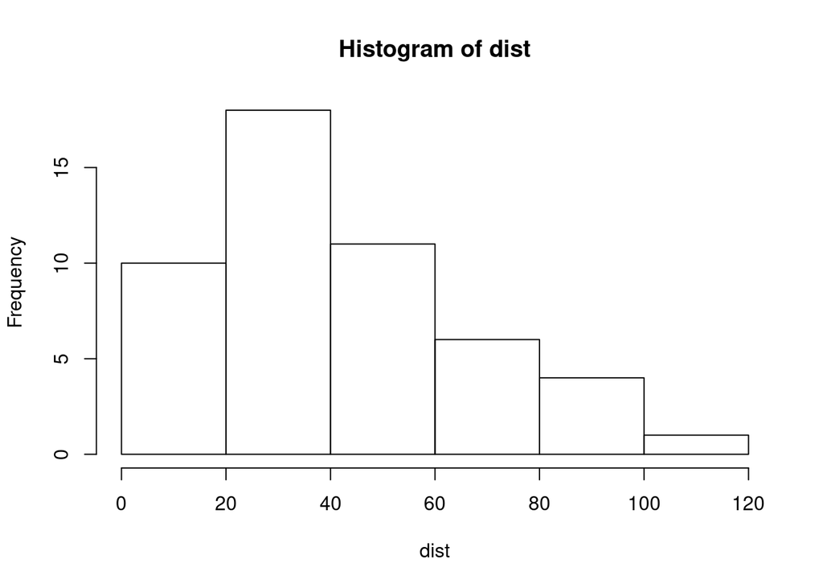

```r
hist(dist) # Histograma de la distancia de frenado
```

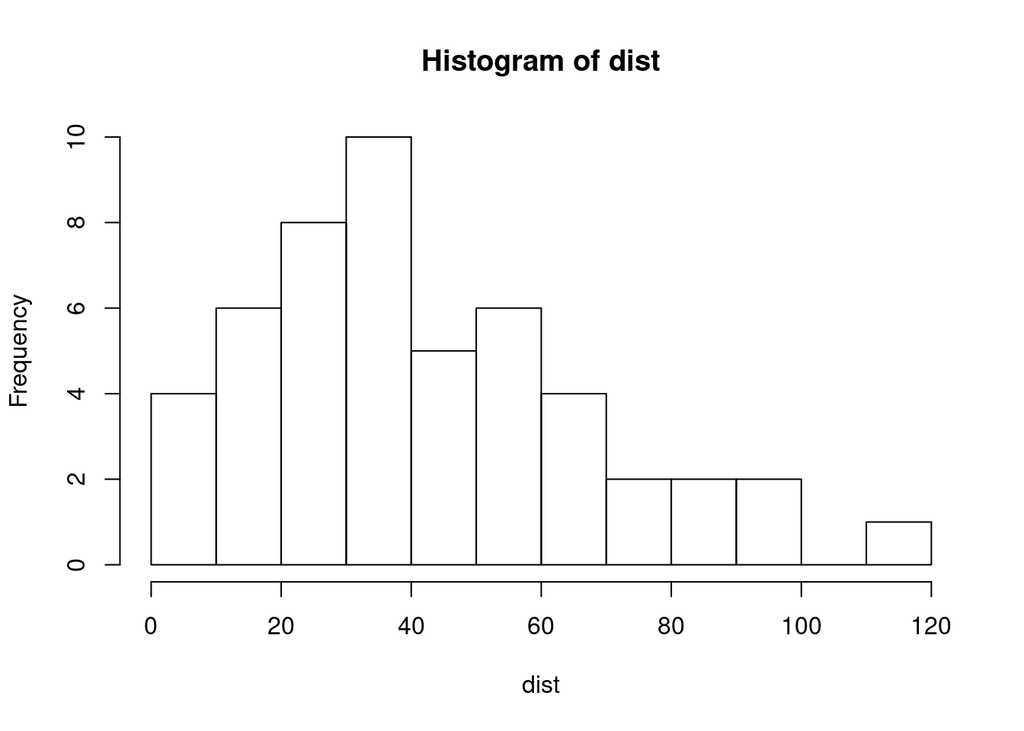

```r
hist(dist,10) # Histograma de la distancia con 10 bins
```

La función `plot(x,y,...)` puede usarse para producir una gráfica del vector `y` contra el vector `x`. Al escribir `?plot` en la consola podemos ver mas detalles de la función.

#### (b) Usar la función `plot(x,y)` para crear una gráfica de dispersión de dist contra speed.

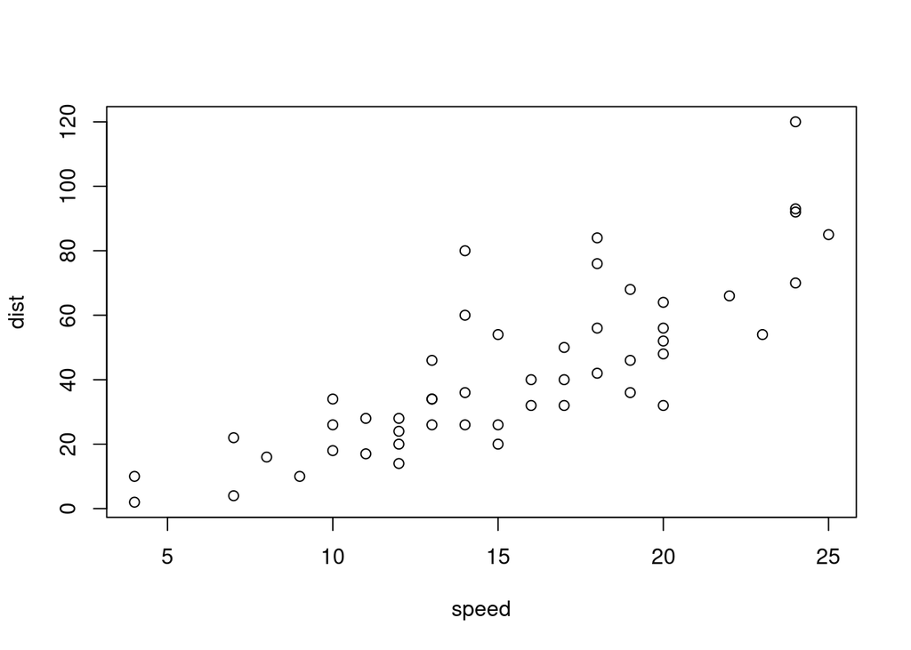

```r
plot(speed,dist)
```

LA función `summary()` produce un sumario con estadisticas descriptivas de las variables en el conjunto de datos cars.

```r
summary(cars)
```

```
##      speed           dist
##  Min.   : 4.0   Min.   :  2.00
##  1st Qu.:12.0   1st Qu.: 26.00
##  Median :15.0   Median : 36.00
##  Mean   :15.4   Mean   : 42.98
##  3rd Qu.:19.0   3rd Qu.: 56.00
##  Max.   :25.0   Max.   :120.00
```